# linear_regression_causal

```python
jupyter nbconvert --to html your_notebook.ipynb
```

[output not shown]

```python
import warnings
warnings.filterwarnings('ignore')

import pandas as pd
import numpy as np
import graphviz as gr
from matplotlib import style
import seaborn as sns
from matplotlib import pyplot as plt
style.use("ggplot")
import statsmodels.formula.api as smf
import matplotlib
from cycler import cycler

default_cycler = (cycler(color=['0.3', '0.5', '0.7', '0.5']))

color=['0.3', '0.5', '0.7', '0.9']
linestyle=['-', '--', ':', '-.']
marker=['o', 'v', 'd', 'p']

plt.rc('axes', prop_cycle=default_cycler)

gr.set_default_format("png");
```

```python
g_risk = gr.Digraph(graph_attr={'rankdir':"LR"})

g_risk.edge("Risk", "X")
g_risk.edge("X", "Credit Limit")
g_risk.edge("X", "Default")
g_risk.edge("Credit Limit", "Default", color='red')

g_risk
# we care about causal effect of credit limit on default
# but there are some other factors that impact credit limit, say a person's credit history
# The person's credit history is also associated with her default rate
```

[figure not shown]

#### Regression A/B Tests

```python
import pandas as pd

risk_data = pd.read_csv("https://raw.githubusercontent.com/matheusfacure/causal-inference-in-python-code/main/causal-inference-in-python/data/risk_data.csv")
```

```python
model = smf.ols('default ~ credit_limit', data=risk_data).fit()
model.summary().tables[1]
```

|  | coef | std err | t | P>\|t\| | [0.025 | 0.975] |
| --- | --- | --- | --- | --- | --- | --- |
| Intercept | 0.2192 | 0.004 | 59.715 | 0.000 | 0.212 | 0.226 |
| credit_limit | -2.402e-05 | 1.16e-06 | -20.689 | 0.000 | -2.63e-05 | -2.17e-05 |

```python
risk_data.head()
```

|  | wage | educ | exper | married | credit_score1 | credit_score2 | credit_limit | default |
| --- | --- | --- | --- | --- | --- | --- | --- | --- |
| 0 | 950.0 | 11 | 16 | 1 | 500.0 | 518.0 | 3200.0 | 0 |
| 1 | 780.0 | 11 | 7 | 1 | 414.0 | 429.0 | 1700.0 | 0 |
| 2 | 1230.0 | 14 | 9 | 1 | 586.0 | 571.0 | 4200.0 | 0 |
| 3 | 1040.0 | 15 | 8 | 1 | 379.0 | 411.0 | 1500.0 | 0 |
| 4 | 1000.0 | 16 | 1 | 1 | 379.0 | 518.0 | 1800.0 | 0 |

```python
plt_df = (risk_data
          .assign(size=1)
          .groupby("credit_limit")
          .agg({"default": "mean", "size":sum})
          .reset_index()
          .assign(prediction = lambda d: model.predict(d)))
```

```python
plt_df.head(2)
```

|  | credit_limit | default | size | prediction |
| --- | --- | --- | --- | --- |
| 0 | 200.0 | 0.211445 | 1031 | 0.214418 |
| 1 | 300.0 | 0.156863 | 255 | 0.212016 |

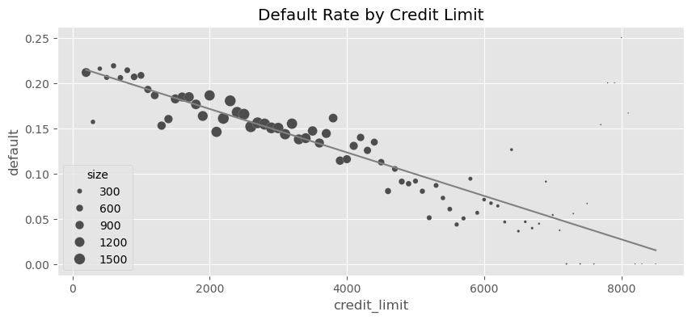

```python
plt.figure(figsize=(10, 4))

sns.scatterplot(data=plt_df,
               x="credit_limit",
               y="default",
               size="size",
               sizes=(1, 100))
plt.plot(plt_df["credit_limit"], plt_df["prediction"], color="C1")
plt.title("Default Rate by Credit Limit")
```

```python
# the relationship between risk and credit limit is negative due to confounding
```

### II. Frisch-Waugh-Lovell Theorem

#### a. Debiasing Model, $T \sim X$

```python
debiasing_model = smf.ols(
    "credit_limit ~ wage + credit_score1 + credit_score2",
    data=risk_data
).fit()
```

```python
debiasing_model.summary().tables[1]
```

|  | coef | std err | t | P>\|t\| | [0.025 | 0.975] |
| --- | --- | --- | --- | --- | --- | --- |
| Intercept | -39.5745 | 24.953 | -1.586 | 0.113 | -88.483 | 9.334 |
| wage | 1.8386 | 0.016 | 118.127 | 0.000 | 1.808 | 1.869 |
| credit_score1 | 1.8926 | 0.053 | 36.044 | 0.000 | 1.790 | 1.996 |
| credit_score2 | 0.0918 | 0.044 | 2.087 | 0.037 | 0.006 | 0.178 |

```python
risk_data_deb = risk_data.assign(
    credit_limit_res = (debiasing_model.resid + risk_data['credit_limit'].mean())
) # res + credit_limit not necessary for debiasing,
## but putting credit_limit on the scale as the original data
```

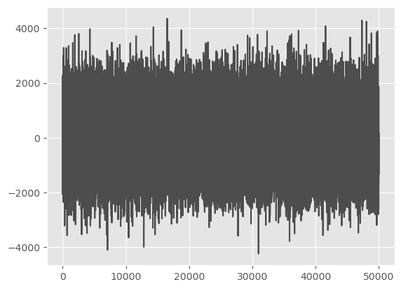

```python
debiasing_model.resid.plot()
# notice how now the residual is centered around 0
```

```python
# now regressing Y on the debiased/residualized version of the treatmeent
# we get the effect of credit limit on Y while controling for the confounders

model_w_deb_data = smf.ols('default ~ credit_limit_res',
                          data=risk_data_deb).fit()
model_w_deb_data.summary().tables[1]
```

|  | coef | std err | t | P>\|t\| | [0.025 | 0.975] |
| --- | --- | --- | --- | --- | --- | --- |
| Intercept | 0.1421 | 0.005 | 30.001 | 0.000 | 0.133 | 0.151 |
| credit_limit_res | 3.063e-06 | 1.56e-06 | 1.957 | 0.050 | -4.29e-09 | 6.13e-06 |

```python
risk_data_deb.head()
```

|  | wage | educ | exper | married | credit_score1 | credit_score2 | credit_limit | default | credit_limit_res |
| --- | --- | --- | --- | --- | --- | --- | --- | --- | --- |
| 0 | 950.0 | 11 | 16 | 1 | 500.0 | 518.0 | 3200.0 | 0 | 3347.583906 |
| 1 | 780.0 | 11 | 7 | 1 | 414.0 | 429.0 | 1700.0 | 0 | 2331.086567 |
| 2 | 1230.0 | 14 | 9 | 1 | 586.0 | 571.0 | 4200.0 | 0 | 3665.134174 |
| 3 | 1040.0 | 15 | 8 | 1 | 379.0 | 411.0 | 1500.0 | 0 | 1720.933260 |
| 4 | 1000.0 | 16 | 1 | 1 | 379.0 | 518.0 | 1800.0 | 0 | 2084.659827 |

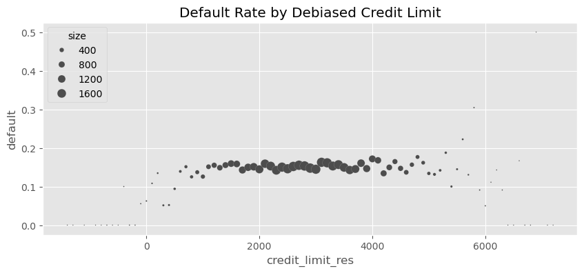

```python
plt_df = (risk_data_deb
          .assign(size=1)
          .assign(credit_limit_res = lambda d: d["credit_limit_res"].round(-2))
          .groupby("credit_limit_res")
          .agg({"default": "mean", "size":sum})
          .reset_index())

plt.figure(figsize=(10,4))
sns.scatterplot(data=plt_df,
                x="credit_limit_res",
                y="default",
                size="size",
                sizes=(1,100))

plt.title("Default Rate by Debiased Credit Limit")
```

#### b. Denosing Model $Y \sim X$

```python
denoising_model = smf.ols(
    'default ~ wage + credit_score1 + credit_score2',
    data=risk_data_deb
).fit()

risk_data_denoise = risk_data_deb.assign(
             default_res=denoising_model.resid + risk_data_deb["default"].mean()
)
```

#### c. Final Outcome Model

Now we have:

$$\tilde{Y}, \tilde{T}$$

```python
model_w_orthogonal = smf.ols("default_res ~ credit_limit_res",
                            data=risk_data_denoise).fit()
model_w_orthogonal.summary().tables[1]
```

|  | coef | std err | t | P>\|t\| | [0.025 | 0.975] |
| --- | --- | --- | --- | --- | --- | --- |
| Intercept | 0.1421 | 0.005 | 30.458 | 0.000 | 0.133 | 0.151 |
| credit_limit_res | 3.063e-06 | 1.54e-06 | 1.987 | 0.047 | 4.17e-08 | 6.08e-06 |

Notice that the parameter estimate for T is exactlyu the same as the one we got in the debiasing step and the direct regression.

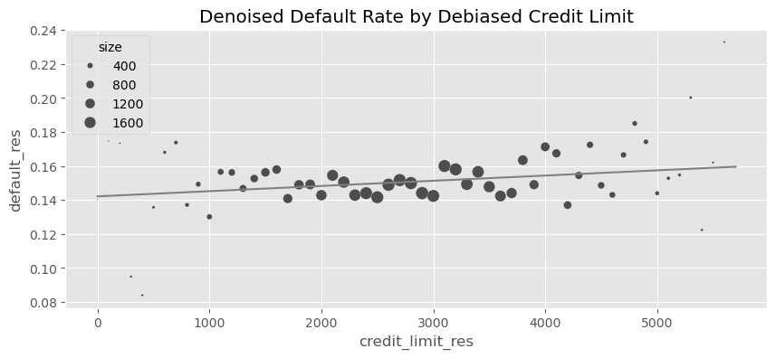

```python
plt_df = (risk_data_denoise
          .assign(size=1)
          .assign(credit_limit_res = lambda d: d["credit_limit_res"].round(-2))
          .groupby("credit_limit_res")
          .agg({"default_res": "mean", "size":sum})
          .query("size>30")
          .reset_index()
          .assign(prediction = lambda d: model_w_orthogonal.predict(d)))

plt.figure(figsize=(10,4))
sns.scatterplot(data=plt_df,
                x="credit_limit_res",
                y="default_res",
                size="size",
                sizes=(1,100))

plt.plot(plt_df["credit_limit_res"], plt_df["prediction"], c="C1")

plt.title("Denoised Default Rate by Debiased Credit Limit")
```

### Calculate SE of Regression Estimator

```python
model_se = smf.ols("default ~ wage + credit_score1 + credit_score2",
                  data=risk_data).fit()
model_se.bse["wage"]
```

```
5.364242347548205e-06
```

```python
model_wage_aux = smf.ols(
            'wage ~ credit_score1 + credit_score2',
            data=risk_data
).fit()


se_formula = (np.std(model_se.resid) / (np.std(model_wage_aux.resid)*np.sqrt(len(risk_data)-4)))
```

```python
se_formula
```

```
5.364242347548201e-06
```

### III. Linear Regression Causal Effect Estimate With Control

```python
risk_data.groupby(["credit_score1", "credit_score2"]).size().head()
```

```
credit_score1  credit_score2
34.0           339.0            1
               500.0            1
52.0           518.0            1
69.0           214.0            1
               357.0            1
dtype: int64
```

```python
formula = 'default ~ credit_limit + wage+credit_score1+credit_score2'
model = smf.ols(formula, data=risk_data).fit()
model.summary().tables[1]
```

|  | coef | std err | t | P>\|t\| | [0.025 | 0.975] |
| --- | --- | --- | --- | --- | --- | --- |
| Intercept | 0.4037 | 0.009 | 46.939 | 0.000 | 0.387 | 0.421 |
| credit_limit | 3.063e-06 | 1.54e-06 | 1.987 | 0.047 | 4.16e-08 | 6.08e-06 |
| wage | -8.822e-05 | 6.07e-06 | -14.541 | 0.000 | -0.000 | -7.63e-05 |
| credit_score1 | -4.175e-05 | 1.83e-05 | -2.278 | 0.023 | -7.77e-05 | -5.82e-06 |
| credit_score2 | -0.0003 | 1.52e-05 | -20.055 | 0.000 | -0.000 | -0.000 |

```python
X_cols = ["credit_limit", "wage", "credit_score1", "credit_score2"]
X = risk_data[X_cols].assign(intercep=1)
y = risk_data["default"]
```

```python
import numpy as np
```

```python
def regress(y, X):
    return np.linalg.inv(X.T.dot(X)).dot(X.T.dot(y))
```

```python
beta = regress(y, X)
beta
```

```
array([ 3.06252773e-06, -8.82159125e-05, -4.17472814e-05, -3.03928359e-04,
        4.03661277e-01])
```

### IV. Nonlinearities in Linear Regression

```python
spend_data = pd.read_csv("https://raw.githubusercontent.com/matheusfacure/causal-inference-in-python-code/main/causal-inference-in-python/data/spend_data.csv")
```

```python
spend_data.head()
```

|  | wage | educ | exper | married | credit_score1 | credit_score2 | credit_limit | spend |
| --- | --- | --- | --- | --- | --- | --- | --- | --- |
| 0 | 950.0 | 11 | 16 | 1 | 500.0 | 518.0 | 3200.0 | 3848 |
| 1 | 780.0 | 11 | 7 | 1 | 414.0 | 429.0 | 1700.0 | 3144 |
| 2 | 1230.0 | 14 | 9 | 1 | 586.0 | 571.0 | 4200.0 | 4486 |
| 3 | 1040.0 | 15 | 8 | 1 | 379.0 | 411.0 | 1500.0 | 3327 |
| 4 | 1000.0 | 16 | 1 | 1 | 379.0 | 518.0 | 1800.0 | 3508 |

```python
# let us now plot spend by credit lines for multiple wage levels

spend_plot = spend_data.groupby(['wage', 'credit_limit'])[['spend']].mean().reset_index()
spend_plot
```

|  | wage | credit_limit | spend |
| --- | --- | --- | --- |
| 0 | 120.0 | 500.0 | 1480.0 |
| 1 | 120.0 | 1800.0 | 2427.0 |
| 2 | 140.0 | 800.0 | 1870.0 |
| 3 | 140.0 | 2000.0 | 2692.0 |
| 4 | 150.0 | 1300.0 | 2324.0 |
| ... | ... | ... | ... |
| 8353 | 3260.0 | 3700.0 | 6433.0 |
| 8354 | 3260.0 | 4600.0 | 6671.0 |
| 8355 | 3260.0 | 6600.0 | 7252.0 |
| 8356 | 3270.0 | 5800.0 | 7077.0 |
| 8357 | 3310.0 | 4700.0 | 6934.0 |

8358 rows × 3 columns

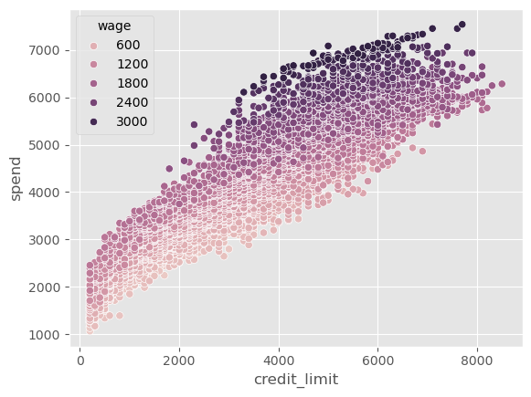

```python
sns.scatterplot(x='credit_limit', y='spend', hue='wage', data=spend_plot)
```

Notice that the higher the credit limit, the lower the slope of the curve.

The effect of credit limit on spend diminishes as your increase credit limit.

```python
# what we can do now is to linearizing the treatment

spend_plot.head()
```

|  | wage | credit_limit | spend |
| --- | --- | --- | --- |
| 0 | 120.0 | 500.0 | 1480.0 |
| 1 | 120.0 | 1800.0 | 2427.0 |
| 2 | 140.0 | 800.0 | 1870.0 |
| 3 | 140.0 | 2000.0 | 2692.0 |
| 4 | 150.0 | 1300.0 | 2324.0 |

```python
spend_plot['log_spend'] = np.log(spend_plot['spend'])
spend_plot['credit_limit_sqrt'] = np.sqrt(spend_plot['credit_limit'])
```

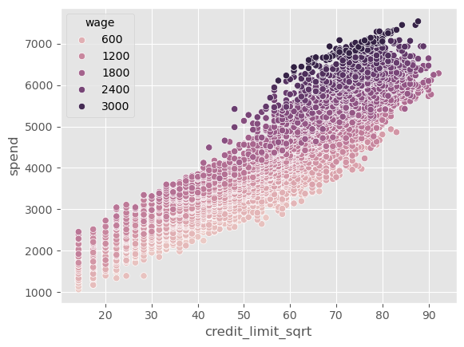

```python
sns.scatterplot(x='credit_limit_sqrt', y='spend', hue='wage', data=spend_plot)
```

The model now become: $$spend_i = \beta_0+ \beta_1 \sqrt{CreditLine_i} + e_i$$

```python
model_spend = smf.ols(
                 'spend ~ np.sqrt(credit_limit)',data=spend_data
).fit()

model_spend.summary().tables[1]
```

|  | coef | std err | t | P>\|t\| | [0.025 | 0.975] |
| --- | --- | --- | --- | --- | --- | --- |
| Intercept | 493.0044 | 6.501 | 75.832 | 0.000 | 480.262 | 505.747 |
| np.sqrt(credit_limit) | 63.2525 | 0.122 | 519.268 | 0.000 | 63.014 | 63.491 |

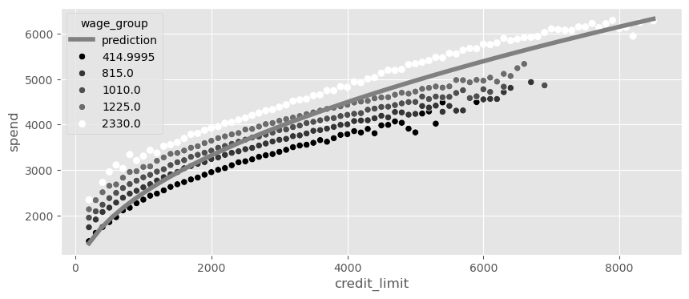

```python
plt_df = (spend_data
          .assign(wage_group = lambda d: pd.IntervalIndex(pd.qcut(d["wage"], 5)).mid)
          .groupby(["wage_group", "credit_limit"])
          [["spend"]]
          .mean()
          .reset_index()
         )

x = np.linspace(plt_df["credit_limit"].min(), plt_df["credit_limit"].max())

plt.figure(figsize=(10,4))
plt.plot(x, model_spend.params[0] + model_spend.params[1]*np.sqrt(x), color="C1", label="prediction", lw=4)
plt.legend()
sns.scatterplot(data=plt_df,
                x="credit_limit",
                y="spend",
                palette="gray",
                hue="wage_group")
```

$$spend_i = \beta_0+ \beta_1 \sqrt{CreditLine_i} + \beta_2 wage_i + e_i$$

```python
model_spend = smf.ols('spend ~ np.sqrt(credit_limit)+wage',
                   data=spend_data).fit()
model_spend.summary().tables[1]
```

|  | coef | std err | t | P>\|t\| | [0.025 | 0.975] |
| --- | --- | --- | --- | --- | --- | --- |
| Intercept | 383.5002 | 2.746 | 139.662 | 0.000 | 378.118 | 388.882 |
| np.sqrt(credit_limit) | 43.8504 | 0.065 | 672.633 | 0.000 | 43.723 | 43.978 |
| wage | 1.0459 | 0.002 | 481.875 | 0.000 | 1.042 | 1.050 |

### V. Nonlinear FWL and Debiasing

1. Find a function F that linearizes the relationship b/w T and Y.
2. A debiasing step: $F(T) \sim X$ to obtain $\tilde{F(T)} = F(T) - \widehat{F(T)}$
3. A denosing step, $Y \sim X$ to obtain $\tilde{Y} = Y -\widehat{Y}$
4. An outcome model, $\tilde{Y} \sim \widetilde{F(T)}$

```python
# F is the squre root in this example

debias_spend_model = smf.ols(f'np.sqrt(credit_limit) ~ wage',
                  data=spend_data).fit()
denoise_spend_model = smf.ols(f'spend ~ wage', data=spend_data).fit()
credit_limit_sqrt_deb = (debias_spend_model.resid
              + np.sqrt(spend_data["credit_limit"]).mean())
spend_den = denoise_spend_model.resid + spend_data["spend"].mean()
spend_data_deb = (spend_data
       .assign(credit_limit_sqrt_deb = credit_limit_sqrt_deb,
               spend_den = spend_den))
final_model = smf.ols(f'spend_den ~ credit_limit_sqrt_deb',
           data=spend_data_deb).fit()
final_model.summary().tables[1]
```

|  | coef | std err | t | P>\|t\| | [0.025 | 0.975] |
| --- | --- | --- | --- | --- | --- | --- |
| Intercept | 1493.6990 | 3.435 | 434.818 | 0.000 | 1486.966 | 1500.432 |
| credit_limit_sqrt_deb | 43.8504 | 0.065 | 672.640 | 0.000 | 43.723 | 43.978 |

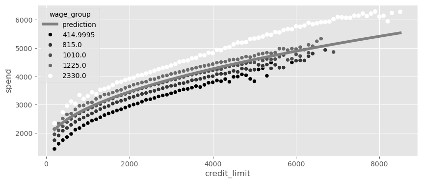

```python
plt_df = (spend_data
          .assign(wage_group = lambda d: pd.IntervalIndex(pd.qcut(d["wage"], 5)).mid)
          .groupby(["wage_group", "credit_limit"])
          [["spend"]]
          .mean()
          .reset_index())

x = np.linspace(plt_df["credit_limit"].min(), plt_df["credit_limit"].max())

plt.figure(figsize=(10,4))
plt.plot(x, (final_model.params[0]
             + final_model.params[1]*np.sqrt(x)),
         color="C1", label="prediction", lw=4)

plt.legend()

sns.scatterplot(data=plt_df,
                x="credit_limit",
                y="spend",
                palette="gray",
                hue="wage_group")
```

### VI. Conditionally Random Experiments

```python
risk_data_rnd = pd.read_csv("https://raw.githubusercontent.com/matheusfacure/causal-inference-in-python-code/main/causal-inference-in-python/data/risk_data_rnd.csv")
risk_data_rnd.head()
```

|  | wage | educ | exper | married | credit_score1 | credit_score2 | credit_score1_buckets | credit_limit | default |
| --- | --- | --- | --- | --- | --- | --- | --- | --- | --- |
| 0 | 890.0 | 11 | 16 | 1 | 490.0 | 500.0 | 400 | 5400.0 | 0 |
| 1 | 670.0 | 11 | 7 | 1 | 196.0 | 481.0 | 200 | 3800.0 | 0 |
| 2 | 1220.0 | 14 | 9 | 1 | 392.0 | 611.0 | 400 | 5800.0 | 0 |
| 3 | 1210.0 | 15 | 8 | 1 | 627.0 | 519.0 | 600 | 6500.0 | 0 |
| 4 | 900.0 | 16 | 1 | 1 | 275.0 | 519.0 | 200 | 2100.0 | 0 |

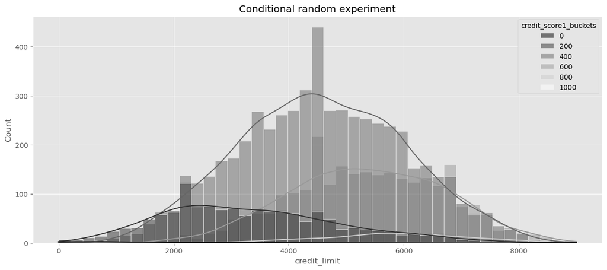

```python
plt.figure(figsize=(15,6))
sns.histplot(data=risk_data_rnd,
             x="credit_limit",
             hue="credit_score1_buckets",
             kde=True,
             palette="gray");
plt.title("Conditional random experiment")
```

For the high-risk bucket:

- randomize credit lines by sampling from a distribution with a lower average

For low-risk bucket:

- randomize credit lines by sampling from a distribution with a higher average

**Beta Sampling**

Credit limit was sampled from Beta Distribution. The Beta Distribution can be understood as generalization of the uniform distribution, making it handy when we want the sample to be confined to a specific range.

#### Dummy Variable

If we do nothing: $$default_i = \beta_0 + \beta_1 lines_i +e_i$$

```python
model = smf.ols("default ~ credit_limit", data=risk_data_rnd).fit()
model.summary().tables[1]
```

|  | coef | std err | t | P>\|t\| | [0.025 | 0.975] |
| --- | --- | --- | --- | --- | --- | --- |
| Intercept | 0.1369 | 0.009 | 15.081 | 0.000 | 0.119 | 0.155 |
| credit_limit | -9.344e-06 | 1.85e-06 | -5.048 | 0.000 | -1.3e-05 | -5.72e-06 |

```python
risk_data_dummies = (
    risk_data_rnd.join(pd.get_dummies(risk_data_rnd['credit_score1_buckets'],
                                     prefix='sb',
                                     drop_first=True))
)
# join combined 2 df based on index
```

```python
risk_data_dummies
```

|  | wage | educ | exper | married | credit_score1 | credit_score2 | credit_score1_buckets | credit_limit | default | sb_200 | sb_400 | sb_600 | sb_800 | sb_1000 |
| --- | --- | --- | --- | --- | --- | --- | --- | --- | --- | --- | --- | --- | --- | --- |
| 0 | 890.0 | 11 | 16 | 1 | 490.0 | 500.0 | 400 | 5400.0 | 0 | False | True | False | False | False |
| 1 | 670.0 | 11 | 7 | 1 | 196.0 | 481.0 | 200 | 3800.0 | 0 | True | False | False | False | False |
| 2 | 1220.0 | 14 | 9 | 1 | 392.0 | 611.0 | 400 | 5800.0 | 0 | False | True | False | False | False |
| 3 | 1210.0 | 15 | 8 | 1 | 627.0 | 519.0 | 600 | 6500.0 | 0 | False | False | True | False | False |
| 4 | 900.0 | 16 | 1 | 1 | 275.0 | 519.0 | 200 | 2100.0 | 0 | True | False | False | False | False |
| ... | ... | ... | ... | ... | ... | ... | ... | ... | ... | ... | ... | ... | ... | ... |
| 9995 | 990.0 | 13 | 15 | 1 | 490.0 | 537.0 | 400 | 5200.0 | 0 | False | True | False | False | False |
| 9996 | 950.0 | 10 | 19 | 1 | 392.0 | 481.0 | 400 | 3200.0 | 0 | False | True | False | False | False |
| 9997 | 480.0 | 12 | 14 | 1 | 412.0 | 537.0 | 400 | 1900.0 | 0 | False | True | False | False | False |
| 9998 | 1110.0 | 11 | 17 | 0 | 608.0 | 481.0 | 600 | 5400.0 | 0 | False | False | True | False | False |
| 9999 | 940.0 | 12 | 16 | 0 | 451.0 | 407.0 | 400 | 5500.0 | 0 | False | True | False | False | False |

10000 rows × 14 columns

$$default_i = \beta_0 + \beta_1 lines_i +\theta G_i +e_i$$

```python
model = smf.ols(
                 "default ~ credit_limit + sb_200+sb_400+sb_600+sb_800+sb_1000",
                 data=risk_data_dummies).fit()

model.summary().tables[1]
```

|  | coef | std err | t | P>\|t\| | [0.025 | 0.975] |
| --- | --- | --- | --- | --- | --- | --- |
| Intercept | 0.2253 | 0.056 | 4.000 | 0.000 | 0.115 | 0.336 |
| sb_200[T.True] | -0.0559 | 0.057 | -0.981 | 0.327 | -0.168 | 0.056 |
| sb_400[T.True] | -0.1442 | 0.057 | -2.538 | 0.011 | -0.256 | -0.033 |
| sb_600[T.True] | -0.2148 | 0.057 | -3.756 | 0.000 | -0.327 | -0.103 |
| sb_800[T.True] | -0.2489 | 0.060 | -4.181 | 0.000 | -0.366 | -0.132 |
| sb_1000[T.True] | -0.2541 | 0.094 | -2.715 | 0.007 | -0.438 | -0.071 |
| credit_limit | 4.652e-06 | 2.02e-06 | 2.305 | 0.021 | 6.97e-07 | 8.61e-06 |

```python
model = smf.ols("default ~ credit_limit + C(credit_score1_buckets)",
								data=risk_data_rnd).fit()
model.summary().tables[1]
```

|  | coef | std err | t | P>\|t\| | [0.025 | 0.975] |
| --- | --- | --- | --- | --- | --- | --- |
| Intercept | 0.2253 | 0.056 | 4.000 | 0.000 | 0.115 | 0.336 |
| C(credit_score1_buckets)[T.200] | -0.0559 | 0.057 | -0.981 | 0.327 | -0.168 | 0.056 |
| C(credit_score1_buckets)[T.400] | -0.1442 | 0.057 | -2.538 | 0.011 | -0.256 | -0.033 |
| C(credit_score1_buckets)[T.600] | -0.2148 | 0.057 | -3.756 | 0.000 | -0.327 | -0.103 |
| C(credit_score1_buckets)[T.800] | -0.2489 | 0.060 | -4.181 | 0.000 | -0.366 | -0.132 |
| C(credit_score1_buckets)[T.1000] | -0.2541 | 0.094 | -2.715 | 0.007 | -0.438 | -0.071 |
| credit_limit | 4.652e-06 | 2.02e-06 | 2.305 | 0.021 | 6.97e-07 | 8.61e-06 |

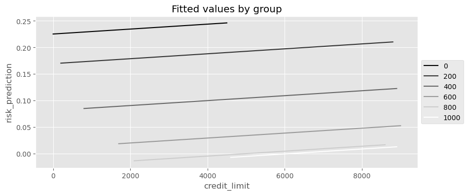

```python
plt_df = (risk_data_rnd
          .assign(risk_prediction = model.fittedvalues)
          .groupby(["credit_limit", "credit_score1_buckets"])
          ["risk_prediction"]
          .mean()
          .reset_index())

plt.figure(figsize=(10,4))
sns.lineplot(data=plt_df,
             x="credit_limit", y="risk_prediction", hue="credit_score1_buckets", palette = 'gray');
plt.title("Fitted values by group")
plt.legend(loc='center left', bbox_to_anchor=(1, 0.5))
```

### VII. Saturated Regression Model

Recall how compare the means between treated and control group is like running a regresion with a binary treatment.

```python
def regress(df, t, y):
    return smf.ols(f"{y}~{t}", data=df).fit().params[t]
effect_by_group = (risk_data_rnd
                .groupby("credit_score1_buckets")
                .apply(regress, y="default", t="credit_limit"))
effect_by_group
```

```
credit_score1_buckets
0      -0.000071
200     0.000007
400     0.000005
600     0.000003
800     0.000002
1000    0.000000
dtype: float64
```

This give an effect by group. We have to decide how to average them out.

- weighted average? where weights are the size of each group

```python
group_size = risk_data_rnd.groupby("credit_score1_buckets").size()
```

```python
ate = (effect_by_group * group_size).sum() / group_size.sum()
ate
```

```
4.4904456287487265e-06
```

```python
model = smf.ols("default ~ credit_limit * C(credit_score1_buckets)",
                             data=risk_data_rnd).fit()
model.summary().tables[1]
```

|  | coef | std err | t | P>\|t\| | [0.025 | 0.975] |
| --- | --- | --- | --- | --- | --- | --- |
| Intercept | 0.3137 | 0.077 | 4.086 | 0.000 | 0.163 | 0.464 |
| C(credit_score1_buckets)[T.200] | -0.1521 | 0.079 | -1.926 | 0.054 | -0.307 | 0.003 |
| C(credit_score1_buckets)[T.400] | -0.2339 | 0.078 | -3.005 | 0.003 | -0.386 | -0.081 |
| C(credit_score1_buckets)[T.600] | -0.2957 | 0.080 | -3.690 | 0.000 | -0.453 | -0.139 |
| C(credit_score1_buckets)[T.800] | -0.3227 | 0.111 | -2.919 | 0.004 | -0.539 | -0.106 |
| C(credit_score1_buckets)[T.1000] | -0.3137 | 0.428 | -0.733 | 0.464 | -1.153 | 0.525 |
| credit_limit | -7.072e-05 | 4.45e-05 | -1.588 | 0.112 | -0.000 | 1.66e-05 |
| credit_limit:C(credit_score1_buckets)[T.200] | 7.769e-05 | 4.48e-05 | 1.734 | 0.083 | -1.01e-05 | 0.000 |
| credit_limit:C(credit_score1_buckets)[T.400] | 7.565e-05 | 4.46e-05 | 1.696 | 0.090 | -1.18e-05 | 0.000 |
| credit_limit:C(credit_score1_buckets)[T.600] | 7.398e-05 | 4.47e-05 | 1.655 | 0.098 | -1.37e-05 | 0.000 |
| credit_limit:C(credit_score1_buckets)[T.800] | 7.286e-05 | 4.65e-05 | 1.567 | 0.117 | -1.83e-05 | 0.000 |
| credit_limit:C(credit_score1_buckets)[T.1000] | 7.072e-05 | 8.05e-05 | 0.878 | 0.380 | -8.71e-05 | 0.000 |

```python
(model.params[model.params.index.str.contains("credit_limit:")]
              + model.params["credit_limit"]).round(9)
```

```
credit_limit:C(credit_score1_buckets)[T.200]     0.000007
credit_limit:C(credit_score1_buckets)[T.400]     0.000005
credit_limit:C(credit_score1_buckets)[T.600]     0.000003
credit_limit:C(credit_score1_buckets)[T.800]     0.000002
credit_limit:C(credit_score1_buckets)[T.1000]    0.000000
dtype: float64
```

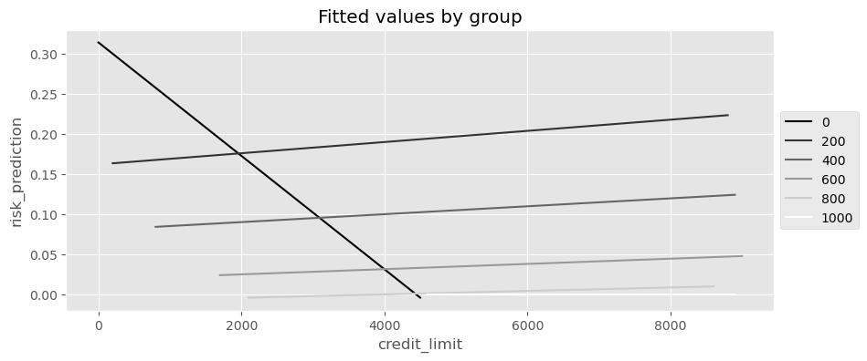

```python
plt_df = (risk_data_rnd
          .assign(risk_prediction = model.fittedvalues)
          .groupby(["credit_limit", "credit_score1_buckets"])
          ["risk_prediction"]
          .mean()
          .reset_index())

plt.figure(figsize=(10,4))
sns.lineplot(data=plt_df,
             x="credit_limit", y="risk_prediction", hue="credit_score1_buckets",  palette="gray");
plt.title("Fitted values by group")
plt.legend(loc='center left', bbox_to_anchor=(1, 0.5))
```